# Explore the harmonized OsteoCAR reference

Karla Paniagua

2026-11-16

## Introduction

This notebook checks the harmonized, aggregated OsteoCAR reference created by `scripts/create-reference.R`. The reference combines the primary and metastasis OsteoCAR references into one reference for `SingleR` with a single level of annotation:

- Tumor and Mesenchymal labels come from `Ann_Level1`
- All other (normal) cell type labels come from `Ann_Level2`

Labels are harmonized across the two references, so e.g. T cells from both the primary and metastasis references are labeled `T_cells`.

Here we check that the resulting reference looks as expected:

1. The object has the expected structure, labels, and values
2. Known marker genes are most highly expressed in their expected cell types

## Setup

```r
# Load libraries
suppressPackageStartupMessages({
  library(SingleCellExperiment)
})
```

### Paths

```r
# find the module root, which contains the renv.lock file
module_base <- rprojroot::find_root(rprojroot::is_renv_project)
ref_dir <- file.path(module_base, "references")

# reference type to explore: "patient".
ref_type <- "patient"
ref_file <- file.path(ref_dir, glue::glue("{ref_type}_harmonized_aggr_ref.rds"))

# stop early if the reference file does not exist
stopifnot("Reference file does not exist" = file.exists(ref_file))
```

### Read the reference

```r
# read the aggregated reference RDS file, where each column is a pseudobulk sample for a cell type
ref <- readr::read_rds(ref_file)
ref
```

```
class: SummarizedExperiment
dim: 21332 2177
metadata(0):
assays(1): logcounts
rownames(21332): LINC01409 LINC01128 ... PRR15 AL357793.2
rowData names(0):
colnames(2177): B_cells_1 B_cells_2 ... Tumor_2176 Tumor_2177
colData names(1): label
```

## Structure checks

### Labels

Each label should appear once, with no `primary_`/`metastasis_` prefixes and no `NA` values. The number of pseudobulk samples per label is shown:

```r
# number of pseudobulk samples per label
table(ref$label, useNA = "ifany")
```

```
  Alv_Macrophages           B_cells                DC Endothelial_cells
               27                69                89               205
 Epithelial_cells              Mast       Mesenchymal         Monocytes
              107                42               276                76
         NK_cells           T_cells              TAMs             Tumor
               80               192               420               594
```

### Expression values

The `logcounts` should have no missing values, should not be negative, and no pseudobulk sample should be all zeros.

```r
# extract the logcounts matrix from the reference
mat <- assay(ref, "logcounts")

# summarise the expression values for quality checks
data.frame(
  check = c("Any NA values", "Minimum value", "Maximum value", "Any all-zero columns"),
  result = c(
    anyNA(mat),
    round(min(mat), 3),
    round(max(mat), 3),
    any(colSums(mat) == 0)
  )
)
```

| check | result |
| --- | --- |
| Any NA values | 0.000 |
| Minimum value | 0.000 |
| Maximum value | 8.711 |
| Any all-zero columns | 0.000 |

## Average expression per cell type

To compare cell types, we average the pseudobulk samples within each label. This gives a matrix with one row per gene and one column per cell type.

```r
# average expression of each gene across the pseudobulk samples for each cell type
label_avg <- split(seq_len(ncol(mat)), ref$label) |>
  purrr::map(\(cols) {
    rowMeans(mat[, cols, drop = FALSE])
  }) |>
  do.call(what = cbind)
dim(label_avg)
```

```
[1] 21332    12
```

### Top expressed genes per cell type

```r
# top expressed genes for each cell type
apply(label_avg, 2, \(x) names(sort(x, decreasing = TRUE))[1:10])
```

```
      Alv_Macrophages B_cells   DC        Endothelial_cells Epithelial_cells
 [1,] "MALAT1"        "MALAT1"  "MALAT1"  "MALAT1"          "MALAT1"
 [2,] "NEAT1"         "MT-CO2"  "CD74"    "NEAT1"           "NEAT1"
 [3,] "FTL"           "MT-CO1"  "HLA-DRA" "TCF4"            "MECOM"
 [4,] "PLXDC2"        "MT-CO3"  "MT-CO1"  "PTPRM"           "MBNL1"
 [5,] "MT-CO1"        "MT-ATP6" "TMSB4X"  "MT-CO1"          "ZBTB20"
 [6,] "FTH1"          "B2M"     "MT-CO2"  "LDB2"            "AKAP13"
 [7,] "MT-CO2"        "RPLP1"   "B2M"     "MT-CO2"          "FNDC3B"
 [8,] "MT-CO3"        "IGKC"    "MT-ATP6" "MAGI1"           "MAGI1"
 [9,] "LRMDA"         "MT-ND4"  "MT-CO3"  "MT-CO3"          "PDE4D"
[10,] "B2M"           "RPL10"   "FTH1"    "MT-ATP6"         "NEDD4L"
      Mast      Mesenchymal Monocytes NK_cells  T_cells   TAMs      Tumor
 [1,] "MALAT1"  "MALAT1"    "MALAT1"  "MALAT1"  "MALAT1"  "MALAT1"  "MALAT1"
 [2,] "MT-CO2"  "COL1A1"    "MT-CO1"  "B2M"     "B2M"     "MT-CO1"  "MT-CO2"
 [3,] "TPSB2"   "COL1A2"    "FTH1"    "MT-CO1"  "MT-CO1"  "FTL"     "COL1A1"
 [4,] "MT-CO1"  "MT-CO1"    "FTL"     "MT-CO2"  "MT-ATP6" "MT-CO2"  "MT-CO1"
 [5,] "MT-ATP6" "MT-CO2"    "MT-CO2"  "MT-ATP6" "MT-CO2"  "MT-CO3"  "COL1A2"
 [6,] "B2M"     "MT-CO3"    "MT-CO3"  "MT-CO3"  "MT-CO3"  "MT-ATP6" "MT-CO3"
 [7,] "FTH1"    "RPLP1"     "NEAT1"   "TMSB4X"  "TMSB4X"  "MT-ND4"  "MT-ATP6"
 [8,] "MT-CO3"  "MT-ATP6"   "MT-ATP6" "RPL10"   "RPLP1"   "NEAT1"   "MT-ND4"
 [9,] "MT-ND4"  "VIM"       "B2M"     "RPLP1"   "MT-CYB"  "TMSB4X"  "NEAT1"
[10,] "MT-ND3"  "MT-ND4"    "MT-ND4"  "RPS27"   "MT-ND4"  "B2M"     "RUNX2"
```

[output not shown]

[output cut: 65 more lines]

[output not shown]

## Marker gene heatmap

```r
# read the marker gene table: one row per gene, with its cell type and source
marker_file <- file.path(module_base, "marker-genes", "osteosarcoma-markers.tsv")
marker_df <- readr::read_tsv(marker_file, show_col_types = FALSE)

# cell type order for the heatmap, as listed in the table
cell_types <- unique(marker_df$cell_type)

# check that every cell type in the table is a label in the reference
stopifnot(
  "Marker cell types do not match reference labels" =
    all(cell_types %in% colnames(label_avg))
)
```

Some markers may not be present in the reference, either because they were not in the original OsteoCAR references or because they were not shared between the primary and metastasis references. These markers are missing and will be left out of the heatmap:

```r
# print markers that are not in the reference
setdiff(marker_df$gene_symbol, rownames(label_avg))
```

```
[1] "MS4A1"  "MS4A2"  "CLEC9A"
```

[output not shown]

```r
# keep only markers present in the reference
marker_df <- marker_df[marker_df$gene_symbol %in% rownames(label_avg), ]
```

Expression is scaled across cell types for each gene.

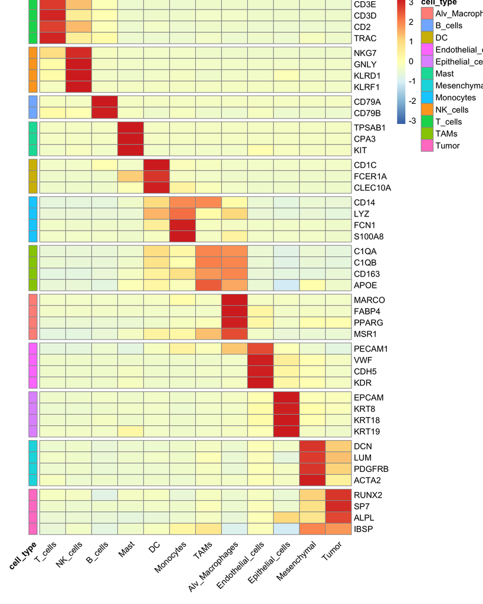

```r
# average expression values for each marker gene across cell types
# with rows as genes and columns as cell types
plot_mat <- label_avg[marker_df$gene_symbol, cell_types]

marker_heatmap <- pheatmap::pheatmap(
  plot_mat,
  scale = "row",
  cluster_rows = FALSE,
  cluster_cols = FALSE,
  # color bar showing which cell type each gene belongs to
  annotation_row = data.frame(
    cell_type = marker_df$cell_type,
    row.names = marker_df$gene_symbol
  ),
  # add a gap between groups of genes belonging to different cell types
  gaps_row = cumsum(table(factor(marker_df$cell_type, levels = cell_types))),
  angle_col = 45,
  # build the heatmap without drawing it yet
  silent = TRUE
)

# add padding (top, right, bottom, left) so rotated labels are not cut off
marker_heatmap$gtable <- gtable::gtable_add_padding(
  marker_heatmap$gtable,
  grid::unit(c(0, 0, 0.5, 2), "cm")
)
# draw the heatmap with added padding
grid::grid.newpage()
grid::grid.draw(marker_heatmap$gtable)
```

## Conclusions

- Marker genes for every cell type are most highly expressed in their expected label, so the aggregated reference profiles are consistent with known biology.
- Some markers are absent from the reference and were not plotted: *MS4A1* (B cells), *MS4A2* (Mast), and *CLEC9A* (DC). B cells are therefore represented by only two markers (*CD79A*, *CD79B*), though both are specific.
- Expected overlaps between related cell types are visible:
  - **Tumor and Mesenchymal** share some signal: Mesenchymal cells express osteoblastic markers (*RUNX2*, *IBSP*), and Tumor cells express Mesenchymal markers (*DCN*, *LUM*, *PDGFRB*).
  - **Myeloid cell types** (Monocytes, DC, TAMs, Alv_Macrophages) share markers such as *CD14*, *LYZ*, and *C1QA*/*C1QB*. This is expected because they come from a common myeloid lineage, and monocytes can differentiate into macrophages and DCs. As a result, misassignments among these cell types are more likely than between distant lineages.
  - **T cells and NK cells** share some signal (*NKG7* in T cells), as expected for cytotoxic lymphocytes.
  - *FCER1A* is expressed in both DC and Mast cells, which is known biology.

## References

- Budhathoki Y, et al. (2026). OsteoCAR: a single-cell atlas for osteosarcoma (preprint). https://doi.org/10.64898/2026.01.13.698472
- Chen LH, et al. (2021). Complement C1q (C1qA, C1qB, and C1qC) may be a potential prognostic factor and an index of tumor microenvironment remodeling in osteosarcoma. *Frontiers in Oncology* 11:642144. https://doi.org/10.3389/fonc.2021.642144
- Cheng S, et al. (2021). A pan-cancer single-cell transcriptional atlas of tumor infiltrating myeloid cells. *Cell* 184(3):792–809. https://doi.org/10.1016/j.cell.2021.01.010
- Gudgeon J, Marín-Rubio JL, Trost M (2022). The role of macrophage scavenger receptor 1 (MSR1) in inflammatory disorders and cancer. *Frontiers in Immunology* 13:1012002. https://doi.org/10.3389/fimmu.2022.1012002
- Hu S, et al. (2026). Lactylation-driven metabolic reprogramming promotes osteosarcoma malignancy via HDGF-mediated proliferation and immune modulation. *Frontiers in Immunology* 17:1836254. https://doi.org/10.3389/fimmu.2026.1836254
- Liu Y, et al. (2021). Single-cell transcriptomics reveals the complexity of the tumor microenvironment of treatment-naive osteosarcoma. *Frontiers in Oncology* 11:709210. https://doi.org/10.3389/fonc.2021.709210
- Palecanda A, et al. (1999). Role of the scavenger receptor MARCO in alveolar macrophage binding of unopsonized environmental particles. *Journal of Experimental Medicine* 189(9):1497–1506. https://doi.org/10.1084/jem.189.9.1497
- Schupp JC, et al. (2021). Integrated single-cell atlas of endothelial cells of the human lung. *Circulation*. https://doi.org/10.1161/CIRCULATIONAHA.120.052318
- Smith MR, Standiford TJ, Reddy RC (2007). PPARs in alveolar macrophage biology. *PPAR Research* 2007:23812. https://doi.org/10.1155/2007/23812
- Song X, et al. (2025). Single-cell transcriptomics reveals the heterogeneity and function of mast cells in human ccRCC. *Frontiers in Immunology*. https://doi.org/10.3389/fimmu.2024.1494025
- Tang F, et al. (2023). A pan-cancer single-cell panorama of human natural killer cells. *Cell* 186(19):4235–4251. https://doi.org/10.1016/j.cell.2023.07.034
- Travaglini KJ, et al. (2020). A molecular cell atlas of the human lung from single-cell RNA sequencing. *Nature* 587:619–625. https://doi.org/10.1038/s41586-020-2922-4
- Villani AC, et al. (2017). Single-cell RNA-seq reveals new types of human blood dendritic cells, monocytes, and progenitors. *Science* 356:eaah4573. https://doi.org/10.1126/science.aah4573
- Xiao J, et al. (2025). Comprehensive analysis of KRT18 as a novel prognostic biomarker and potential target in lung adenocarcinoma. *Clinical and Experimental Medicine* 25:312. https://doi.org/10.1007/s10238-025-01855-0
- Xie Z, et al. (2023). Single-cell analysis unveils activation of mast cells in colorectal cancer microenvironment. *Cell & Bioscience* 13:217. https://doi.org/10.1186/s13578-023-01144-x
- Xiong F, et al. (2022). Keratin 8 is an inflammation-induced and prognosis-related marker for pancreatic adenocarcinoma. *Disease Markers* 2022:8159537. https://doi.org/10.1155/2022/8159537
- Zhou Y, et al. (2020). Single-cell RNA landscape of intratumoral heterogeneity and immunosuppressive microenvironment in advanced osteosarcoma. *Nature Communications* 11:6322. https://doi.org/10.1038/s41467-020-20059-6
- Sun HJ et al. (2026). HERC4 downregulates KRT19 to promote lung adenocarcinoma, migration, invasion and EMT. *Translational Oncology* 63:102593. https://doi.org/10.1016/j.tranon.2025.102593 (PMID: 41192149)